Step1: Read the data provided in the Excel file and ?isolate? the tabulated information into a data.frame class.

```r
#Zuerst die untere Textzeile in der Exeltabelle manuell entfernen
df <- read.table("F:/Uni Marburg/1.Semester/Fernerkundung/mpg-envinsys-plygrnd/mpg-envinfosys-teams-2019-eddi-und-carl/src/hessen_holzeinschlag_1997-2014.csv", header = TRUE, sep = ";", skip = 4)

str(df)
```

```
## 'data.frame':    18 obs. of  7 variables:
##  $ FWJ      : int  1997 1998 1999 2000 2001 2002 2003 2004 2005 2006 ...
##  $ Eiche    : int  155 265 278 204 322 265 404 400 370 388 ...
##  $ Buche    : int  1036 1631 1796 1300 1515 1410 1698 1572 1489 1881 ...
##  $ Buntholz : int  21 36 32 0 0 0 0 0 0 0 ...
##  $ Fichte   : int  1684 1761 1732 1024 1592 2036 2482 2775 2601 2580 ...
##  $ Kiefer   : int  779 951 914 616 706 663 820 757 887 844 ...
##  $ Insgesamt: int  3675 4644 4752 3144 4135 4374 5404 5504 5347 5693 ...
```

Step2: Create a simple visualization which gives a quick, temporally non explicit and descriptive statistical overview of the harvest by tree type and as a total over all trees (i.e. a similar kind of information as provided by the summary function).

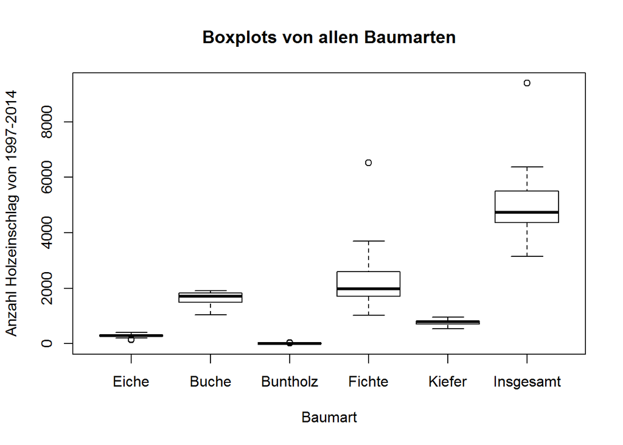

```r
v <- df[,c(2:7)]



boxplot(v, main = "Boxplots von allen Baumarten", xlab="Baumart", ylab="Anzahl Holzeinschlag von 1997-2014")
```

Step3: Create another visualization which - in the same figure panel - shows how each beech harvest over the time span is related to each of the oak, pine, spruce and colored wood harvests in a 2 by 2 grid (i.e. arrange the figures in a 2 columns and 2 rows layout).

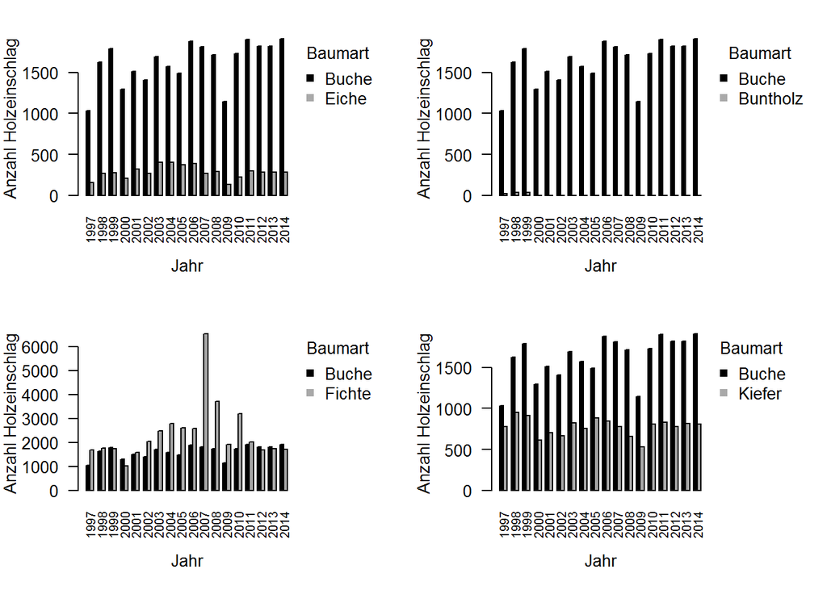

```r
par(mar=c(5,4,2,6))
#Erweiterung des Plotrahmen

par(mfrow = c(2,2))
#Zum Ploten mehrerer Plots innerhalb eines Rahmens in einer 2x2 Anordnung

barplot(t(as.matrix(df[c(3,2)])), width = 8,beside = TRUE, space = c(0,1) ,names.arg = df[,1],las=2,cex.names=0.75,col=c("black","darkgrey"),
        ylab = "Anzahl Holzeinschlag",
        xlab = "Jahr")
legend(x='topleft',legend=c("Buche","Eiche"),cex=1,col=c("black","darkgrey"),title="Baumart",inset=c(1,0), xpd=TRUE, bty="n",pch=15)

# "t"" vor "(as.matrix)" fæ¼ã¹£r Umsortierung der Achsen,
#"inset=c(1,0), xpd=TRUE, bty="n",pch=15 + Z40" zum ploten der Legende auæ¼ã¹¦erhalb der Grafik
#las=2 Zur Ausrichtung des y-Achsenlabels

barplot(t(as.matrix(df[c(3,4)])), width = 8,beside = TRUE, space = c(0,1) ,names.arg = df[,1],las=2,cex.names=0.75,col=c("black","darkgrey"),
        ylab = "Anzahl Holzeinschlag",
        xlab = "Jahr")
legend(x='topleft',legend=c("Buche","Buntholz"),cex=1,col=c("black","darkgrey"),title="Baumart",inset=c(1,0), xpd=TRUE, bty="n",pch=15)

barplot(t(as.matrix(df[c(3,5)])), width = 8,beside = TRUE, space = c(0,1) ,names.arg = df[,1],las=2,cex.names=0.75,col=c("black","darkgrey"),
        ylab = "Anzahl Holzeinschlag",
        xlab = "Jahr")
legend(x='topleft',legend=c("Buche","Fichte"),cex=1,col=c("black","darkgrey"),title="Baumart",inset=c(1,0), xpd=TRUE, bty="n",pch=15)

barplot(t(as.matrix(df[c(3,6)])), width = 8,beside = TRUE, space = c(0,1) ,names.arg = df[,1],las=2,cex.names=0.75,col=c("black","darkgrey"),
        ylab = "Anzahl Holzeinschlag",
        xlab = "Jahr")
legend(x='topleft',legend=c("Buche","Kiefer"),cex=1,col=c("black","darkgrey"),title="Baumart",inset=c(1,0), xpd=TRUE, bty="n",pch=15)
```

Step4: Include your opinion on what could be the key message of these figures in two sentence max.

Betrachtet man die vier Plots in ihrer Gesamtheit faellt auf, dass besonders die Fichte im Jahr 2007 eine exrem hohen Holzeinschlag verzeichnet. Dies ist auf das starke Sturmtief Kyrill vom Januar 2007 zurueckzufueren.  
´´´´